# Kapraun et al. (submitted): Generic Human Gestational Model

## Convert the units:

```r
convert1.units <- c("ng/ml","ng/mL","ug/L","ug/l","ng/mL serum","ng/g",
  "ng/g wet wt.","ppb")

MFdata.httk[MFdata.httk$obs.units%in%convert1.units,"infant"] <-
  MFdata.httk[MFdata.httk$obs.units%in%convert1.units,"infant"] / # ng/ml = ug/L
  MFdata.httk[MFdata.httk$obs.units%in%convert1.units,"AVERAGE_MASS"]  # ug/L -> uM
MFdata.httk[MFdata.httk$obs.units%in%convert1.units,"maternal"] <-
  MFdata.httk[MFdata.httk$obs.units%in%convert1.units,"maternal"] / # ng/ml = ug/L
  MFdata.httk[MFdata.httk$obs.units%in%convert1.units,"AVERAGE_MASS"]  # ug/L -> uM
MFdata.httk[MFdata.httk$obs.units%in%convert1.units,"obs.units"] <- "uM"

convert2.units <- c("mg/L","ppm")

MFdata.httk[MFdata.httk$obs.units%in%convert2.units,"infant"] <-
  MFdata.httk[MFdata.httk$obs.units%in%convert2.units,"infant"] * 1000 / # mg/L = ug/L
  MFdata.httk[MFdata.httk$obs.units%in%convert2.units,"AVERAGE_MASS"]  # ug/L -> uM
MFdata.httk[MFdata.httk$obs.units%in%convert2.units,"maternal"] <-
  MFdata.httk[MFdata.httk$obs.units%in%convert2.units,"maternal"]* 1000 / # mg/L = ug/L
  MFdata.httk[MFdata.httk$obs.units%in%convert2.units,"AVERAGE_MASS"]  # ug/L -> uM
MFdata.httk[MFdata.httk$obs.units%in%convert2.units,"obs.units"] <- "uM"
```

## Compare HTTK predictions with maternal:fetal observations from Aylward 2014

Note that we can’t do an absolute scale comparison (for example, fetal:fetal or maternal:maternal) because we don’t know the dose for the Aylward data but we assume that the maternal:fetal ratio is independent of dose and so we use the plasma ratio at full term (40 weeks) resulting from a 1 mg/kg/day exposure rate starting in week 13.

```r
# Simulate starting from the 13th week of gestation until full term (40 weeks):
times <- sort(unique(c(seq(13 * 7, 40 * 7, 0.25),seq(278,280,.1))))

# For each chemical with maternal-fetal ratio data and HTTK in vitro data:
for (this.id in unique(MFdata.httk$DTXSID))
{
# Load the chemical-specifc paramaters:
  p <- suppressWarnings(parameterize_fetal_pbtk(dtxsid=this.id,
    fetal_fup_adjustment =TRUE,
    suppress.messages=TRUE))
# Skip chemicals where the 95% credible interval for Fup spans more than 0.1 to
# 0.9 (that is, Fup is effectively unknown):
    if (!is.na(p$Funbound.plasma.dist))
  {
    if (as.numeric(strsplit(p$Funbound.plasma.dist,",")[[1]][3])>0.9 &
      as.numeric(strsplit(p$Funbound.plasma.dist,",")[[1]][2])<0.11)
    {
      skip <- TRUE
    } else skip <- FALSE
  } else skip <- FALSE

  if (!skip)
  {
# Solve the PBTK equations for the full simulation time assuming 1 total daily
# dose of 1 mg/kg/day spread out over three evenly spaces exposures:
    out <- suppressWarnings(solve_fetal_pbtk(
      parameters=p,
      dose=0,
      times=times,
      daily.dose=1,
      doses.per.day=3,
      output.units = "uM",
      suppress.messages=TRUE))
# Identify the concentrations from the final (279th) day:
    last.row <- which(out[,"time"]>279)
    last.row <- last.row[!duplicated(out[last.row,"time"])]
# Average over the final day:
    MFdata.httk[MFdata.httk$DTXSID==this.id,"Mat.pred"] <- mean(out[last.row,"Cplasma"])
    MFdata.httk[MFdata.httk$DTXSID==this.id,"Fet.pred"] <- mean(out[last.row,"Cfplasma"])
    MFdata.httk[MFdata.httk$DTXSID==this.id,"MFratio.pred"] <-
      mean(out[last.row,"Cplasma"])/mean(out[last.row,"Cfplasma"])

# Repeat the analysis without the adjustment to fetal Fup:
    p <- suppressWarnings(parameterize_fetal_pbtk(dtxsid=this.id,
      fetal_fup_adjustment =FALSE,
      suppress.messages = TRUE))
    out <- suppressWarnings(solve_fetal_pbtk(
      parameters=p,
      dose=0,
      times=times,
      daily.dose=1,
      doses.per.day=3,
      output.units = "uM",
      maxsteps=1e7,
      suppress.messages = TRUE))

    last.row <- which(out[,"time"]>279) # The whole final day
    last.row <- last.row[!duplicated(out[last.row,"time"])]
    MFdata.httk[MFdata.httk$DTXSID==this.id,"Mat.pred.nofup"] <- mean(out[last.row,"Cplasma"])
    MFdata.httk[MFdata.httk$DTXSID==this.id,"Fet.pred.nofup"] <- mean(out[last.row,"Cfplasma"])
    MFdata.httk[MFdata.httk$DTXSID==this.id,"MFratio.pred.nofup"] <-
      mean(out[last.row,"Cplasma"])/mean(out[last.row,"Cfplasma"])
  }
}

# Something is wrong with cotinine:
MFdata.httk <- subset(MFdata.httk,Chemical!="Cotinine")

max.chem <- MFdata.httk[which(MFdata.httk$MFratio==max(MFdata.httk$MFratio)),]
min.chem <- MFdata.httk[which(MFdata.httk$MFratio==min(MFdata.httk$MFratio)),]
cat(paste("The minimum observed ratio was ",
  signif(min.chem[,"MFratio"],2),
  " for ",
  min.chem[,"Chemical"],
  " and the maximum was ",
  signif(max.chem[,"MFratio"],2),
  " for ",
  max.chem[,"Chemical"],
  ".\n",sep=""))
```

```
#> The minimum observed ratio was 0.11 for 16 and the maximum was 2.9 for 11.
```

## Aylward Ratio figures:

### Clean up repeated observations:

```r
MFdata.main <- NULL
MFdata.outliers <- NULL
for (this.id in unique(MFdata.httk$DTXSID))
{
  this.subset <- subset(MFdata.httk,DTXSID==this.id)
  this.row <- this.subset[1,]
  this.row$N.obs <- dim(this.subset)[1]
  this.row$MFratio <- median(this.subset$MFratio)
  this.row$MFratio.Q25 <- quantile(this.subset$MFratio,0.25)
  this.row$MFratio.Q75 <- quantile(this.subset$MFratio,0.75)
  MFdata.main <- rbind(MFdata.main,this.row)
  this.subset <- subset(this.subset,
    MFratio<this.row$MFratio.Q25 |
    MFratio>this.row$MFratio.Q75)
  MFdata.outliers <- rbind(MFdata.outliers,this.subset)
}
```

### Cord Blood Ratio Predictions without Fup Adjustement:

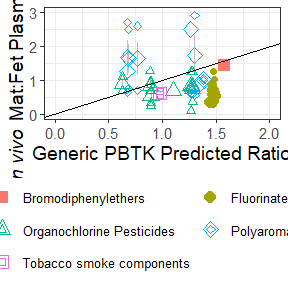

```r
FigCa  <- ggplot(data=MFdata.main) +
  geom_segment(color="grey",aes(
    x=MFratio.pred.nofup,
    y=MFratio.Q25,
    xend=MFratio.pred.nofup,
    yend=MFratio.Q75))+
  geom_point(aes(
    x=MFratio.pred.nofup,
    y=MFratio,
    shape=Chemical.Category,
    color=Chemical.Category),
    size=4)   +
  scale_shape_manual(values=c(15, 16,2, 23, 0, 1, 17, 5, 6))+
  geom_point(data=MFdata.outliers,aes(
    x=MFratio.pred.nofup,
    y=MFratio,
    shape=Chemical.Category,
    color=Chemical.Category),
    size=2)   +
  xlim(0,2) +
  ylim(0,3) +
#   geom_text(aes(x=AUC,y=Critical.concentration,label=Compound.abbrev,color=Chemical)) +
#   scale_y_log10(label=scientific_10) +
#,limits=c(10^-7,100)) +
#   scale_x_log10(label=scientific_10) +
#   ,limits=c(10^-7,100)) +
#    annotation_logticks() +
  geom_abline(slope=1, intercept=0) +
#    geom_abline(slope=1, intercept=1,linetype="dashed") +
#    geom_abline(slope=1, intercept=-1,linetype="dashed") +
  ylab(expression(paste(italic("In vivo")," Mat:Fet Plasma Ratio"))) +
  xlab("Generic PBTK Predicted Ratio") +
#    scale_color_brewer(palette="Set2") +
  theme_bw()  +
  theme(legend.position="bottom")+
  theme( text  = element_text(size=14))+
  theme(legend.text=element_text(size=10))+
  guides(color=guide_legend(title="Class",nrow=3,byrow=TRUE))+
  guides(shape=guide_legend(title="Class",nrow=3,byrow=TRUE))

print(FigCa)
```

### Generate text for results section:

```r
cat(paste("In Figure 4 we compare predictions made with our high-throughput \
human gestational PBTK model with experimental observations on a per chemical \
basis wherever we had both in vitro HTTK data and in vivo observations (",
length(unique(MFdata.main$DTXSID)),
" chemicals).\n",sep=""))
```

```
#> In Figure 4 we compare predictions made with our high-throughput
#> human gestational PBTK model with experimental observations on a per chemical
#> basis wherever we had both in vitro HTTK data and in vivo observations (24 chemicals).
```

```r
repeats <- subset(MFdata.main,N.obs>1)

cat(paste("Multiple observations were available for ",
  dim(repeats)[1],
  " of the chemicals,\n",sep=""))
```

```
#> Multiple observations were available for 18 of the chemicals,
```

```r
max.chem <- repeats[which(repeats$MFratio==max(repeats$MFratio)),]
min.chem <- repeats[which(repeats$MFratio==min(repeats$MFratio)),]

cat(paste("However, among the chemicals with repeated observations, the median \
observations only ranged from ",
  signif(min.chem[,"MFratio"],2),
  " for ",
  min.chem[,"Chemical"],
  " to ",
  signif(max.chem[,"MFratio"],2),
  " for ",
  max.chem[,"Chemical"],
  ".\n",sep=""))
```

```
#> However, among the chemicals with repeated observations, the median
#> observations only ranged from 0.36 for 21 to 1.7 for 11.
```

```r
max.chem <- MFdata.main[which(MFdata.main$MFratio.pred==max(MFdata.main$MFratio.pred,na.rm=TRUE)),]
min.chem <- MFdata.main[which(MFdata.main$MFratio.pred==min(MFdata.main$MFratio.pred,na.rm=TRUE)),]

cat(paste("The predictions for all chemicals ranged from ",
  signif(min.chem[,"MFratio.pred"],2),
  " for ",
  min.chem[,"Chemical"],
  " to ",
  signif(max.chem[,"MFratio.pred"],2),
  " for ",
  max.chem[,"Chemical"],
  ".\n",sep=""))
```

```
#> The predictions for all chemicals ranged from 0.63 for 17 to 1.8 for 1.
```

```r
fit1 <- lm(data=MFdata.main,MFratio~MFratio.pred.nofup)
summary(fit1)
```

```
#>
#> Call:
#> lm(formula = MFratio ~ MFratio.pred.nofup, data = MFdata.main)
#>
#> Residuals:
#>     Min      1Q  Median      3Q     Max
#> -0.5986 -0.3087 -0.1434  0.2120  1.5661
#>
#> Coefficients:
#>                    Estimate Std. Error t value Pr(>|t|)
#> (Intercept)          1.6512     0.4104   4.023  0.00057 ***
#> MFratio.pred.nofup  -0.5681     0.3391  -1.676  0.10799
#> ---
#> Signif. codes:  0 '***' 0.001 '**' 0.01 '*' 0.05 '.' 0.1 ' ' 1
#>
#> Residual standard error: 0.5095 on 22 degrees of freedom
#> Multiple R-squared:  0.1132, Adjusted R-squared:  0.07286
#> F-statistic: 2.807 on 1 and 22 DF,  p-value: 0.108
```

```r
RMSE(fit1)
```

```
#> [1] 0.4878525
```

```r
fit1sub <- lm(data=subset(MFdata.main,
  !(Chemical.Category %in% c(
    "Fluorinated compounds",
    "Polyaromatic Hydrocarbons"))),
  MFratio~MFratio.pred.nofup)
summary(fit1sub)
```

```
#>
#> Call:
#> lm(formula = MFratio ~ MFratio.pred.nofup, data = subset(MFdata.main,
#>     !(Chemical.Category %in% c("Fluorinated compounds", "Polyaromatic Hydrocarbons"))))
#>
#> Residuals:
#>     Min      1Q  Median      3Q     Max
#> -0.1803 -0.1409 -0.1071  0.1233  0.3677
#>
#> Coefficients:
#>                    Estimate Std. Error t value Pr(>|t|)
#> (Intercept)          0.2849     0.3165    0.90    0.398
#> MFratio.pred.nofup   0.4928     0.2801    1.76    0.122
#>
#> Residual standard error: 0.2247 on 7 degrees of freedom
#> Multiple R-squared:  0.3067, Adjusted R-squared:  0.2076
#> F-statistic: 3.096 on 1 and 7 DF,  p-value: 0.1219
```

```r
RMSE(fit1sub)
```

```
#> [1] 0.198205
```

### Cord Blood Ratio Predictions with Fup Adjustement:

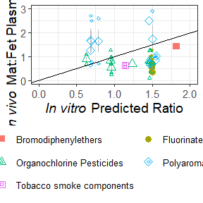

```r
FigCb  <- ggplot(data=MFdata.main) +
  geom_segment(color="grey",aes(
    x=MFratio.pred,
    y=MFratio.Q25,
    xend=MFratio.pred,
    yend=MFratio.Q75))+
  geom_point(aes(
    x=MFratio.pred,
    y=MFratio,
    shape=Chemical.Category,
    color=Chemical.Category),
    size=3)   +
  scale_shape_manual(values=c(15, 16,2, 23, 0, 1, 17, 5, 6))+
  geom_point(data=MFdata.outliers,aes(
    x=MFratio.pred,
    y=MFratio,
    shape=Chemical.Category,
    color=Chemical.Category),
    size=1)   +
  xlim(0,2) +
  ylim(0,3) +
#   geom_text(aes(x=AUC,y=Critical.concentration,label=Compound.abbrev,color=Chemical)) +
#   scale_y_log10(label=scientific_10) +
#,limits=c(10^-7,100)) +
#   scale_x_log10(label=scientific_10) +
#   ,limits=c(10^-7,100)) +
#    annotation_logticks() +
  geom_abline(slope=1, intercept=0) +
#    geom_abline(slope=1, intercept=1,linetype="dashed") +
#    geom_abline(slope=1, intercept=-1,linetype="dashed") +
  ylab(expression(paste(italic("In vivo")," Mat:Fet Plasma Ratio"))) +
  xlab(expression(paste(italic("In vitro")," Predicted Ratio"))) +
#    scale_color_brewer(palette="Set2") +
  theme_bw()  +
  theme(legend.position="bottom")+
  theme( text  = element_text(size=14))+
  theme(legend.text=element_text(size=10))+
  guides(color=guide_legend(title="Class",nrow=3,byrow=TRUE))+
  guides(shape=guide_legend(title="Class",nrow=3,byrow=TRUE))

print(FigCb)
```